# 05_toevoegen_features

Het voorspellen van de bondprijs alleen op basis van historische waarde van de bond is waarschijnlijk nooit erg succesvol. Voor een betere voorspelling zullen we 'leading indicatoren' moeten hebben. Indicatoren die iets zeggen waar de markt naar toe gaat.

Op basis van de literatuurstudie en een selectie van de beschikbare data, zijn de volgende features geselecteerd:

- Remaining Duration
- Theoretical Bond Prices
- Inflation curve
- Term Spread
- Bid Offer Spread

```python
try:
    # %tensorflow_version only exists in Colab.
    %tensorflow_version 2.x
    IS_COLAB = True
except Exception:
    IS_COLAB = False

if IS_COLAB:
    !git clone https://github.com/Merijn68/BondTrading.git
    %pip install -q "ray[tune]" bayesian-optimization
    %pip install loguru tensorflow-addons
    %cd BondTrading
```

[output not shown]

```python
%load_ext autoreload
%autoreload 2

import sys
sys.path.insert(0, "..")

import tensorflow as tf
from tensorflow.keras.callbacks import TensorBoard, EarlyStopping
from tensorflow.keras.callbacks import ReduceLROnPlateau
from tensorflow.keras.optimizers import Adam
from tqdm import tqdm

from matplotlib import pyplot as plt
from pathlib import Path
from sklearn.preprocessing import MinMaxScaler

from src.data import make_dataset, window, split
from src.models import evaluate, hyper
from src.models.base_model import BaseModel, RnnModel
from src.visualization import visualize
```

Door de te verwachten kasstromen te projecteren met de rente van het contract, en te verdisconteren tegen een passend rentepercentage kan een berekening worden gemaakt van de 'theoretische' marktwaarde van de bond. De markt kan tijdelijk de bond door vraag en aanbod hoger of lager prijzen dan deze intrinsieke waarde, maar de verwachting is dat de prijs van de bond hier uiteindelijk toch in de buurt komt.

```
2022-02-09 12:11:13.530 | INFO     | src.data.make_dataset:read_pkl:376 - Load preprocessed isin data
findfont: Font family ['Arial'] not found. Falling back to DejaVu Sans.
```

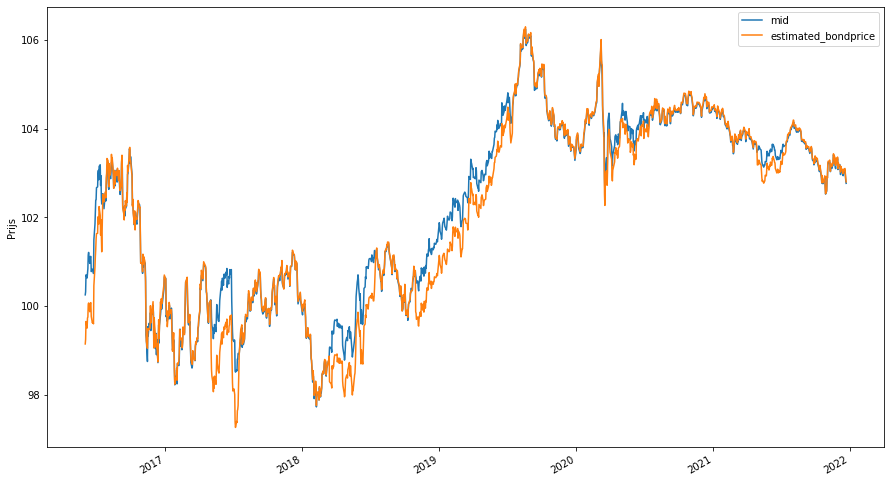

```python
# Add theoretically calculated bond price
df_isin = make_dataset.read_pkl('isin', path = Path("data/processed/"), colab = IS_COLAB)
df_isin.plot(x = 'rate_dt',y = ['mid','estimated_bondprice'], figsize = (15,9), xlabel = ' ', ylabel = 'Prijs')
plt.show()
```

```python
# subset columns and sort on index
df_isin = df_isin[['rate_dt','mid','estimated_bondprice','term_spread','bid_offer_spread_10','10 YEARS']]
df_isin.columns = ['rate_dt','mid','estimated_bondprice','term_spread','bid_offer_spread_10y','inflation_10y']
df_isin = df_isin.set_index('rate_dt')
df_isin = df_isin.sort_index()
```

De dataset wordt weer gesplit in 70% trainingsdata en 30% test data. Dit om deze modellen vergelijkbaar te houden met de modellen die alleen op het signaal getrained werden.

```python
df_train, df_test = split.split_data(df_isin, 0.7)
scaler = MinMaxScaler()
df_train[df_train.columns] = scaler.fit_transform(df_train[df_train.columns])
df_test[df_test.columns] = scaler.transform(df_test[df_test.columns])
```

```
2022-02-09 12:11:22.980 | INFO     | src.data.split:split_data:21 - Train test split data 1413 70.0%,train data 989, test data 424.
```

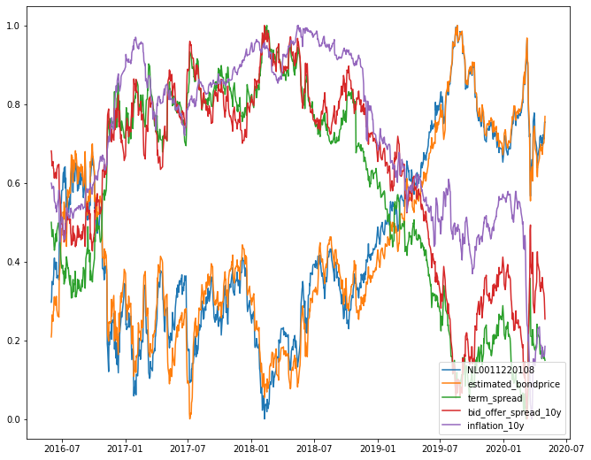

```python
isin = "NL0011220108"  # 10 Years NL Bond, maturity 2025 0.25% coupon
plt.rcParams["figure.figsize"] = [11, 9]
line1, = plt.plot(df_train['mid'], label=isin)
line2, = plt.plot(df_train['estimated_bondprice'], label="estimated_bondprice")
line3, = plt.plot(df_train['term_spread'], label="term_spread")
line4, = plt.plot(df_train['bid_offer_spread_10y'], label="bid_offer_spread_10y")
line4, = plt.plot(df_train['inflation_10y'], label="inflation_10y")
leg = plt.legend(loc='lower right')
```

De correlatie tussen deze items is zeer opvallend. Ik zie nog niet hoe dit mogelijk is. De spread tussen bid en ask prijzen en de spread tussen 2 years en 10 years bonds volgen bijna naadloos een zelfde trend als de ontwikkeling van de marktwaarde van de bond. Wanneer we deze spreads even omdraaien wordt dit nog duidelijker. Een mogelijke verklaring hiervoor zou kunnen zijn dat deze indicatoren worden gebruikt door de algo traders in hun modellen en zodoende feitenlijk de bondprijzen bepalen. In de literatuur heb ik hier geen aanwijzingen voor gevonden.

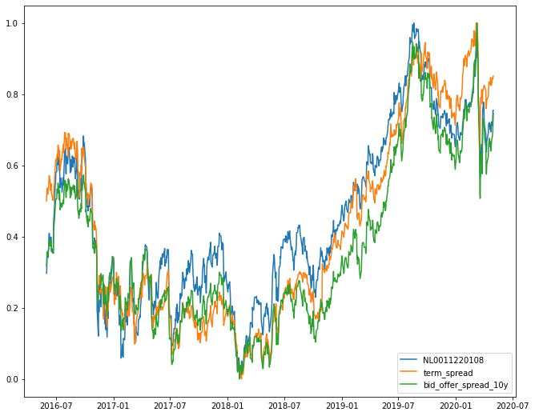

```python
plt.rcParams["figure.figsize"] = [11, 9]
line1, = plt.plot(df_train['mid'], label=isin)
line3, = plt.plot(df_train['term_spread'] * -1 + 1, label="term_spread")
line4, = plt.plot(df_train['bid_offer_spread_10y'] * -1 + 1, label="bid_offer_spread_10y")
leg = plt.legend(loc='lower right')
```

```python
# Create a windowed dataset from the data
window_size = 32
batch_size = 64
shuffle_buffer = 4
horizon = 10
train_set = window.windowed_dataset(df_train, window_size, batch_size, shuffle_buffer, horizon=horizon)
valid_set = window.windowed_dataset(df_test, window_size, batch_size, shuffle_buffer, horizon=horizon)
x, y = next(iter(train_set))
x.shape, y.shape
```

```
2022-02-09 12:11:36.387 | INFO     | src.data.window:windowed_dataset:20 - Split windowed dataset window_size = 32 batch_size =  64, shuffle_buffer =  4 ,horizon =  10
2022-02-09 12:11:39.398 | INFO     | src.data.window:windowed_dataset:20 - Split windowed dataset window_size = 32 batch_size =  64, shuffle_buffer =  4 ,horizon =  10
```

```
(TensorShape([64, 32, 5]), TensorShape([64, 10]))
```

```python
y, yhat = evaluate.naivepredict(df_train.iloc[:, 0].values)
norm = evaluate.mae(y, yhat)
print('1 step Mean Absolute Error: ', evaluate.mae(y, yhat))
# Mean Absolute Error - for horizon
norm = evaluate.calc_mae_for_horizon(train_set, horizon)
print(f'Mean Absolute Error for {horizon} timesteps', norm)
smae = evaluate.ScaledMAE(scale=norm)
```

```
1 step Mean Absolute Error:  0.017672397407386325
Mean Absolute Error for 10 timesteps 0.04321176793667995
```

Het meest eenvoudige RNN model - met een horizon van 10 dagen geeft een foutmarge (Mean Absolute Error) die al beduidend lager ligt dan de naive voorspelling.

```python
result = {}
models = {}
config = {
    'horizon'   : horizon,
    'window'    : window_size,
    'features'  : 5
}
name = 'BaseRnnModel'
model = RnnModel(name,config)
early_stop = EarlyStopping(patience=10, restore_best_weights=True)
lr = 1e-2
model.compile(loss="mse", optimizer=Adam(learning_rate=lr), metrics=["mae", smae])
result[name] = model.fit(train_set,epochs=200, validation_data=valid_set, callbacks=[early_stop], verbose=0)
models[name] = model
print(model.evaluate(valid_set))
```

```
[0.0010991531889885664, 0.0277663916349411, 0.6425654888153076]
```

De visualisatie laat zien dat het model te eenvoudig is. Het model laat bijna geen onderscheid zien tussen de voorspellingen voor de verschillende tijdsstappen.

```
findfont: Font family ['Arial'] not found. Falling back to DejaVu Sans.
```

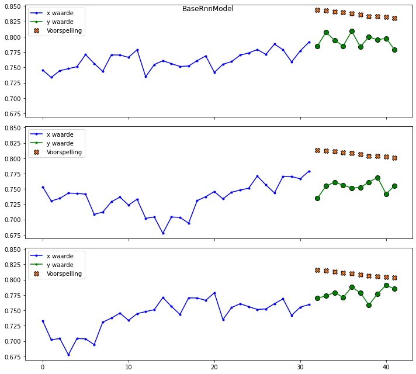

```python
fig = visualize.plot_example(
    valid_set,
    window_size = window_size,
    horizon = horizon,
    examples = 3,
    model = model,
    figurepath = Path("reports/figures"))
```

```python
# Remove log files before tuning models
if IS_COLAB:
  !rm -rf logs/
else:
  !del logs /Q
  !del %USERPROFILE%\AppData\Local\Temp\.tensorboard-info\*.* /Q

%load_ext tensorboard
```

```python
reduce_lr = ReduceLROnPlateau(monitor='smae', factor=0.8,
                              patience=5, min_lr=1e-5)

key = "Adam"
name = f"16_RNN_NO_CONV_{key}"
logdir = Path("logs") / name
tb = TensorBoard(logdir, histogram_freq=1)

config = {
    'window'        :   window_size,
    'units'         :   16,
    'hidden'        :   1,
    'horizon'       :   horizon,
    'features'      :   5
}
model = RnnModel(name,config)
opt = tf.keras.optimizers.get(key)
opt.momentum = 0.9
opt.learning_rate = 0.01

model.compile(loss="mse", optimizer=opt, metrics=["mae", "mape", smae])
result[name] = model.fit(train_set,epochs=200,callbacks=[tb, early_stop, reduce_lr],
                        validation_data=valid_set, verbose=0)
models[name] = model
print("Model: " + model.name, model.evaluate(valid_set))
```

```
Model: 16_RNN_NO_CONV_Adam [0.0006074187695048749, 0.019397608935832977, 2.7315011024475098, 0.4488964378833771]
```

Vervolgens kijken we weer of de optimizer hier nog een verschil maakt. Andere optimizers leiden niet direct tot betere resultaten. De patience en factor voor de learning rate reductie is wel belangrijk hierbij.

```python
config = {
    "window"            : window_size,
    "units"             : 16,
    "hidden"            : 1,
    "horizon"           : horizon,
    "features"          : 5
}

for key in tqdm(["Adam", "SGD", "RMSprop"]):

    name = f"GRU_{key}"
    logdir = Path("logs") / name
    tb = TensorBoard(logdir, histogram_freq=1)

    opt = tf.keras.optimizers.get(key)
    opt.momentum = 0.9
    opt.learning_rate = 0.01

    model = RnnModel(name,config)
    model.compile(loss="mse",
          optimizer=opt,
          metrics=["mae", "mape", smae])

    result[name] = model.fit(train_set,epochs=200,callbacks=[tb, early_stop, reduce_lr],
                            validation_data=valid_set, verbose=0)
    models[name] = model
    print('opt:', key, model.evaluate(valid_set))
```

```
opt: Adam [0.0007428371463902295, 0.020676739513874054, 2.9341962337493896, 0.47849783301353455]
```

```
opt: SGD [0.003644947661086917, 0.03979248180985451, 5.6216583251953125, 0.9208714365959167]
```

```
opt: RMSprop [0.0015325045678764582, 0.03148674964904785, 4.531654357910156, 0.7286614775657654]
```

```python
%tensorboard --logdir logs
```

```python
from ray.tune.sample import qrandint
# Hypertune

from ray import tune
config = {
    "datadir" : Path("data").absolute(),
    "grace_period" : 3,
    "local_dir" : "logs",
    "epochs" : 20,
    "samples" : 25,
    "window" : tune.qrandint(5, 30, 5),
    "type" : tune.choice(["GRU", "LSTM"]),
    "optimizer" : tune.choice(["Adam", "RMSprop"]),
    "hidden" : tune.randint(1, 4),
    "units" : tune.qrandint(16, 256, 16),
    "batch_size": tune.qrandint(32, 256, 64),
    "shuffle_buffer": tune.randint(4, 16),
    "horizon" : 10,
    "features" : 5
}

config_conv = {
    "datadir" : Path("data").absolute(),
    "grace_period" : 3,
    "local_dir" : "logs",
    "epochs" : 20,
    "samples" : 25,
    "window" : tune.qrandint(5, 30, 5),
    "filters" : tune.qrandint(6, 32, 4),
    "kernel" : tune.randint(1, 16),
    "type" : tune.choice(["GRU", "LSTM"]),
    "optimizer" : tune.choice(["Adam", "RMSprop"]),
    "hidden" : tune.randint(1, 4),
    "units" : tune.qrandint(16, 256, 16),
    "activation": tune.choice(["relu", "tanh", None]),
    "batch_size": tune.qrandint(32, 256, 64),
    "shuffle_buffer": tune.randint(4, 16),
    "horizon" : 10,
    "features" : 5
}
```

```python
analysis = hyper.hypertune(df_train, df_test, config)
```

== Status ==  
Current time: 2022-02-09 12:39:00 (running for 00:07:42.85)  
Memory usage on this node: 3.2/12.7 GiB  
Using AsyncHyperBand: num_stopped=23 Bracket: Iter 192.000: None | Iter 48.000: None | Iter 12.000: -0.0014591955114156008 | Iter 3.000: -0.009572268463671207  
Resources requested: 0/2 CPUs, 0/1 GPUs, 0.0/6.35 GiB heap, 0.0/3.17 GiB objects (0.0/1.0 accelerator_type:K80)  
Current best trial: 2a1f2_00009 with val_loss=0.00076868332689628 and parameters={'datadir': PosixPath('/content/BondTrading/data'), 'grace_period': 3, 'local_dir': 'logs', 'epochs': 20, 'samples': 25, 'window': 20, 'type': 'GRU', 'optimizer': 'Adam', 'hidden': 2, 'units': 224, 'batch_size': 128, 'shuffle_buffer': 8, 'horizon': 10, 'features': 5, 'filters': 0, 'kernel': 1, 'activation': None, 'dropout': 0, 'loss': 'mse', 'loss_alpha': 0}  
Result logdir: /content/BondTrading/logs/hypertune  
Number of trials: 25/25 (25 TERMINATED)

| Trial name | status | loc | batch_size | hidden | optimizer | shuffle_buffer | type | units | window | iter | total time (s) | val_loss | val_mae |
| --- | --- | --- | --- | --- | --- | --- | --- | --- | --- | --- | --- | --- | --- |
| wrapper_2a1f2_00000 | TERMINATED | 172.28.0.2:8856 | 128 | 2 | RMSprop | 12 | LSTM | 224 | 25 | 20 | 23.0822 | 0.000992493 | 0.0258778 |
| wrapper_2a1f2_00001 | TERMINATED | 172.28.0.2:8857 | 64 | 2 | RMSprop | 11 | GRU | 80 | 10 | 12 | 16.2418 | 0.00281876 | 0.0430361 |
| wrapper_2a1f2_00002 | TERMINATED | 172.28.0.2:9364 | 64 | 3 | RMSprop | 11 | GRU | 112 | 15 | 12 | 21.3823 | 0.0020373 | 0.0374728 |
| wrapper_2a1f2_00003 | TERMINATED | 172.28.0.2:9560 | 128 | 1 | RMSprop | 7 | LSTM | 48 | 30 | 3 | 9.24743 | 0.0567846 | 0.200549 |
| wrapper_2a1f2_00004 | TERMINATED | 172.28.0.2:9644 | 128 | 1 | RMSprop | 6 | LSTM | 128 | 25 | 3 | 9.84089 | 0.0682683 | 0.247904 |
| wrapper_2a1f2_00005 | TERMINATED | 172.28.0.2:9730 | 128 | 2 | RMSprop | 12 | GRU | 16 | 10 | 3 | 11.5936 | 0.207515 | 0.399107 |
| wrapper_2a1f2_00006 | TERMINATED | 172.28.0.2:9814 | 256 | 1 | Adam | 6 | GRU | 32 | 15 | 3 | 8.97368 | 0.158719 | 0.343947 |
| wrapper_2a1f2_00007 | TERMINATED | 172.28.0.2:9900 | 128 | 3 | RMSprop | 14 | GRU | 80 | 20 | 3 | 13.8463 | 0.0565539 | 0.217829 |
| wrapper_2a1f2_00008 | TERMINATED | 172.28.0.2:9986 | 192 | 3 | Adam | 4 | LSTM | 64 | 20 | 3 | 15.734 | 0.041357 | 0.190335 |
| wrapper_2a1f2_00009 | TERMINATED | 172.28.0.2:10070 | 128 | 2 | Adam | 8 | GRU | 224 | 20 | 20 | 21.2934 | 0.000768683 | 0.0221454 |
| wrapper_2a1f2_00010 | TERMINATED | 172.28.0.2:10362 | 192 | 2 | RMSprop | 4 | GRU | 48 | 25 | 3 | 11.2794 | 0.0533074 | 0.194019 |
| wrapper_2a1f2_00011 | TERMINATED | 172.28.0.2:10448 | 256 | 1 | Adam | 5 | GRU | 160 | 10 | 3 | 9.32822 | 0.0619488 | 0.218581 |
| wrapper_2a1f2_00012 | TERMINATED | 172.28.0.2:10533 | 192 | 3 | RMSprop | 10 | LSTM | 208 | 15 | 3 | 13.6555 | 0.223515 | 0.467143 |
| wrapper_2a1f2_00013 | TERMINATED | 172.28.0.2:10619 | 128 | 3 | RMSprop | 15 | LSTM | 144 | 20 | 12 | 18.8809 | 0.00206075 | 0.0369749 |
| wrapper_2a1f2_00014 | TERMINATED | 172.28.0.2:10813 | 128 | 1 | RMSprop | 15 | GRU | 208 | 30 | 3 | 9.57824 | 0.0362863 | 0.17049 |
| wrapper_2a1f2_00015 | TERMINATED | 172.28.0.2:10897 | 128 | 1 | Adam | 10 | LSTM | 176 | 20 | 3 | 9.60103 | 0.0712324 | 0.242956 |
| wrapper_2a1f2_00016 | TERMINATED | 172.28.0.2:10984 | 64 | 1 | Adam | 14 | LSTM | 208 | 15 | 12 | 13.983 | 0.00146429 | 0.0313961 |
| wrapper_2a1f2_00017 | TERMINATED | 172.28.0.2:11178 | 64 | 1 | Adam | 15 | LSTM | 240 | 10 | 12 | 14.5282 | 0.0018994 | 0.036519 |
| wrapper_2a1f2_00018 | TERMINATED | 172.28.0.2:11370 | 64 | 3 | RMSprop | 12 | LSTM | 208 | 25 | 3 | 14.3707 | 0.0537114 | 0.198742 |
| wrapper_2a1f2_00019 | TERMINATED | 172.28.0.2:11456 | 128 | 3 | Adam | 11 | GRU | 192 | 25 | 12 | 19.624 | 0.0014592 | 0.0312208 |
| wrapper_2a1f2_00020 | TERMINATED | 172.28.0.2:11649 | 128 | 2 | RMSprop | 6 | LSTM | 176 | 10 | 3 | 13.8244 | 0.12796 | 0.338581 |
| wrapper_2a1f2_00021 | TERMINATED | 172.28.0.2:11735 | 64 | 3 | RMSprop | 4 | GRU | 80 | 25 | 12 | 19.3723 | 0.00301193 | 0.0461498 |
| wrapper_2a1f2_00022 | TERMINATED | 172.28.0.2:11929 | 128 | 2 | RMSprop | 6 | GRU | 112 | 10 | 3 | 11.5404 | 0.0231197 | 0.129277 |
| wrapper_2a1f2_00023 | TERMINATED | 172.28.0.2:12013 | 192 | 1 | Adam | 15 | LSTM | 128 | 20 | 3 | 9.02641 | 0.0553223 | 0.20996 |
| wrapper_2a1f2_00024 | TERMINATED | 172.28.0.2:12099 | 192 | 2 | Adam | 6 | GRU | 192 | 25 | 3 | 11.3405 | 0.0339933 | 0.155597 |

```
2022-02-09 12:39:00,244	INFO tune.py:636 -- Total run time: 468.69 seconds (462.83 seconds for the tuning loop).
```

```python
config = analysis.get_best_config()
config
```

```
{'batch_size': 128,
 'datadir': PosixPath('/content/BondTrading/data'),
 'epochs': 20,
 'features': 5,
 'grace_period': 3,
 'hidden': 2,
 'horizon': 10,
 'local_dir': 'logs',
 'optimizer': 'Adam',
 'samples': 25,
 'shuffle_buffer': 8,
 'type': 'GRU',
 'units': 224,
 'window': 20}
```

```python
window_size = config["window"]
horizon = config["horizon"]
train_set = window.windowed_dataset(
    df_train, window_size, batch_size=config['batch_size'], shuffle_buffer=config['shuffle_buffer'], horizon=horizon
)
valid_set = window.windowed_dataset(
    df_train, window_size, batch_size=config['batch_size'], shuffle_buffer=config['shuffle_buffer'], horizon=horizon
)

name = "hypertuned"
logdir = Path("logs") / name
tb = TensorBoard(logdir, histogram_freq=1)

opt = tf.keras.optimizers.get(config["optimizer"])
opt.momentum = 0.9
opt.learning_rate = 0.01
model = RnnModel(name, config)
model.compile(loss="mse", optimizer=opt, metrics=["mae", "mape", smae])

result[name] = model.fit(
        train_set,
        epochs=150,
        validation_data=valid_set,
        callbacks=[tb, reduce_lr, early_stop],
    )
models[name] = model
```

```
2022-02-09 12:51:41.139 | INFO     | src.data.window:windowed_dataset:20 - Split windowed dataset window_size = 20 batch_size =  128, shuffle_buffer =  8 ,horizon =  10
2022-02-09 12:51:41.198 | INFO     | src.data.window:windowed_dataset:20 - Split windowed dataset window_size = 20 batch_size =  128, shuffle_buffer =  8 ,horizon =  10
```

```python
analysis = hyper.hypertune(df_train, df_test, config_conv)
```

== Status ==  
Current time: 2022-02-09 13:05:43 (running for 00:09:25.59)  
Memory usage on this node: 3.7/12.7 GiB  
Using AsyncHyperBand: num_stopped=17 Bracket: Iter 192.000: None | Iter 48.000: None | Iter 12.000: -0.0013073014561086893 | Iter 3.000: -0.011774254962801933  
Resources requested: 0/2 CPUs, 0/1 GPUs, 0.0/6.35 GiB heap, 0.0/3.17 GiB objects (0.0/1.0 accelerator_type:K80)  
Current best trial: ac077_00023 with val_loss=0.0007052546716295183 and parameters={'datadir': PosixPath('/content/BondTrading/data'), 'grace_period': 3, 'local_dir': 'logs', 'epochs': 20, 'samples': 25, 'window': 5, 'filters': 20, 'kernel': 3, 'type': 'GRU', 'optimizer': 'Adam', 'hidden': 1, 'units': 80, 'activation': 'tanh', 'batch_size': 64, 'shuffle_buffer': 4, 'horizon': 10, 'features': 5, 'dropout': 0, 'loss': 'mse', 'loss_alpha': 0}  
Result logdir: /content/BondTrading/logs/hypertune  
Number of trials: 25/25 (25 TERMINATED)

| Trial name | status | loc | activation | batch_size | filters | hidden | kernel | optimizer | shuffle_buffer | type | units | window | iter | total time (s) | val_loss | val_mae |
| --- | --- | --- | --- | --- | --- | --- | --- | --- | --- | --- | --- | --- | --- | --- | --- | --- |
| wrapper_ac077_00000 | TERMINATED | 172.28.0.2:13192 |  | 256 | 16 | 1 | 6 | RMSprop | 5 | GRU | 48 | 10 | 20 | 22.8902 | 0.0226156 | 0.125232 |
| wrapper_ac077_00001 | TERMINATED | 172.28.0.2:13486 | tanh | 64 | 12 | 3 | 7 | Adam | 8 | LSTM | 64 | 5 | 20 | 25.5568 | 0.00304588 | 0.0464789 |
| wrapper_ac077_00002 | TERMINATED | 172.28.0.2:13780 | relu | 64 | 20 | 1 | 11 | RMSprop | 15 | GRU | 112 | 25 | 20 | 22.3664 | 0.00174939 | 0.0339409 |
| wrapper_ac077_00003 | TERMINATED | 172.28.0.2:14072 | tanh | 192 | 24 | 1 | 7 | RMSprop | 9 | GRU | 208 | 15 | 20 | 22.0504 | 0.00079034 | 0.0217923 |
| wrapper_ac077_00004 | TERMINATED | 172.28.0.2:14366 | relu | 64 | 8 | 3 | 10 | RMSprop | 15 | GRU | 144 | 30 | 3 | 15.3616 | 0.040054 | 0.191012 |
| wrapper_ac077_00005 | TERMINATED | 172.28.0.2:14454 | relu | 64 | 8 | 1 | 5 | RMSprop | 15 | GRU | 176 | 20 | 3 | 10.4396 | 0.114028 | 0.32756 |
| wrapper_ac077_00006 | TERMINATED | 172.28.0.2:14542 |  | 192 | 8 | 1 | 6 | RMSprop | 4 | GRU | 112 | 10 | 3 | 10.0303 | 0.0454295 | 0.181445 |
| wrapper_ac077_00007 | TERMINATED | 172.28.0.2:14628 |  | 128 | 8 | 1 | 12 | Adam | 4 | LSTM | 64 | 10 | 3 | 12.7384 | 0.0598122 | 0.22089 |
| wrapper_ac077_00008 | TERMINATED | 172.28.0.2:14716 | tanh | 64 | 24 | 2 | 7 | Adam | 4 | LSTM | 224 | 15 | 3 | 14.8905 | 0.0574026 | 0.231462 |
| wrapper_ac077_00009 | TERMINATED | 172.28.0.2:14804 |  | 192 | 16 | 3 | 10 | Adam | 7 | GRU | 176 | 20 | 20 | 26.2529 | 0.00107915 | 0.0245864 |
| wrapper_ac077_00010 | TERMINATED | 172.28.0.2:15098 | relu | 192 | 28 | 3 | 9 | Adam | 6 | GRU | 240 | 30 | 3 | 14.6842 | 0.0357826 | 0.153213 |
| wrapper_ac077_00011 | TERMINATED | 172.28.0.2:15186 | tanh | 192 | 12 | 3 | 8 | Adam | 6 | GRU | 64 | 15 | 12 | 21.1396 | 0.00203095 | 0.0360495 |
| wrapper_ac077_00012 | TERMINATED | 172.28.0.2:15382 | tanh | 64 | 24 | 1 | 6 | Adam | 13 | LSTM | 80 | 20 | 20 | 23.9384 | 0.00130086 | 0.0297778 |
| wrapper_ac077_00013 | TERMINATED | 172.28.0.2:15676 | tanh | 128 | 16 | 2 | 15 | RMSprop | 15 | GRU | 112 | 10 | 3 | 14.5099 | 0.0603865 | 0.224634 |
| wrapper_ac077_00014 | TERMINATED | 172.28.0.2:15764 |  | 192 | 8 | 2 | 10 | RMSprop | 11 | GRU | 192 | 10 | 3 | 12.2541 | 0.0689333 | 0.248489 |
| wrapper_ac077_00015 | TERMINATED | 172.28.0.2:15852 |  | 128 | 20 | 2 | 12 | Adam | 14 | GRU | 96 | 10 | 12 | 17.1131 | 0.00184267 | 0.0355079 |
| wrapper_ac077_00016 | TERMINATED | 172.28.0.2:16048 | tanh | 128 | 16 | 1 | 14 | Adam | 13 | LSTM | 48 | 25 | 3 | 12.4238 | 0.0243926 | 0.139007 |
| wrapper_ac077_00017 | TERMINATED | 172.28.0.2:16134 | relu | 192 | 8 | 3 | 3 | Adam | 6 | GRU | 96 | 25 | 20 | 26.3695 | 0.00111107 | 0.0258297 |
| wrapper_ac077_00018 | TERMINATED | 172.28.0.2:16428 |  | 64 | 24 | 3 | 12 | Adam | 4 | LSTM | 128 | 10 | 12 | 22.6008 | 0.00221191 | 0.0404404 |
| wrapper_ac077_00019 | TERMINATED | 172.28.0.2:16626 | relu | 64 | 8 | 3 | 4 | RMSprop | 4 | LSTM | 240 | 10 | 12 | 23.5034 | 0.00234997 | 0.0403388 |
| wrapper_ac077_00020 | TERMINATED | 172.28.0.2:16824 |  | 128 | 20 | 1 | 3 | Adam | 15 | LSTM | 112 | 30 | 12 | 17.3217 | 0.00181161 | 0.0316694 |
| wrapper_ac077_00021 | TERMINATED | 172.28.0.2:17020 | relu | 128 | 16 | 1 | 8 | Adam | 11 | GRU | 208 | 15 | 3 | 12.4547 | 0.0263325 | 0.144009 |
| wrapper_ac077_00022 | TERMINATED | 172.28.0.2:17108 | relu | 64 | 24 | 3 | 9 | RMSprop | 13 | LSTM | 256 | 25 | 3 | 16.1845 | 0.023674 | 0.12649 |
| wrapper_ac077_00023 | TERMINATED | 172.28.0.2:17196 | tanh | 64 | 20 | 1 | 3 | Adam | 4 | GRU | 80 | 5 | 20 | 19.8899 | 0.000705255 | 0.0205352 |
| wrapper_ac077_00024 | TERMINATED | 172.28.0.2:17488 | tanh | 192 | 32 | 2 | 8 | RMSprop | 13 | LSTM | 48 | 15 | 3 | 12.5804 | 0.0249413 | 0.142352 |

```
2022-02-09 13:05:43,775	INFO tune.py:636 -- Total run time: 565.74 seconds (565.57 seconds for the tuning loop).
```

```python
config = analysis.get_best_config()
config
```

```
{'activation': 'tanh',
 'batch_size': 64,
 'datadir': PosixPath('/content/BondTrading/data'),
 'epochs': 20,
 'features': 5,
 'filters': 20,
 'grace_period': 3,
 'hidden': 1,
 'horizon': 10,
 'kernel': 3,
 'local_dir': 'logs',
 'optimizer': 'Adam',
 'samples': 25,
 'shuffle_buffer': 4,
 'type': 'GRU',
 'units': 80,
 'window': 5}
```

```python
from tensorflow.python.framework.ops import name_scope_v2
window_size = config["window"]
horizon = config["horizon"]
train_set = window.windowed_dataset(
    df_train, window_size, batch_size=config['batch_size'], shuffle_buffer=config['shuffle_buffer'], horizon=horizon
)
valid_set = window.windowed_dataset(
    df_train, window_size, batch_size=config['batch_size'], shuffle_buffer=config['shuffle_buffer'], horizon=horizon
)

name = "hypertuned_conv"
logdir = Path("logs") / name
tb = TensorBoard(logdir, histogram_freq=1)


opt = tf.keras.optimizers.get(config["optimizer"])
opt.momentum = 0.9
opt.learning_rate = 0.01
model = RnnModel(name, config)
model.compile(loss="mse", optimizer=opt, metrics=["mae", "mape", smae])

result[name] = model.fit(
        train_set,
        epochs=150,
        validation_data=valid_set,
        callbacks=[reduce_lr, early_stop],
    )
models[name] = model
```

```
2022-02-09 13:05:59.177 | INFO     | src.data.window:windowed_dataset:20 - Split windowed dataset window_size = 5 batch_size =  64, shuffle_buffer =  4 ,horizon =  10
2022-02-09 13:05:59.222 | INFO     | src.data.window:windowed_dataset:20 - Split windowed dataset window_size = 5 batch_size =  64, shuffle_buffer =  4 ,horizon =  10
```

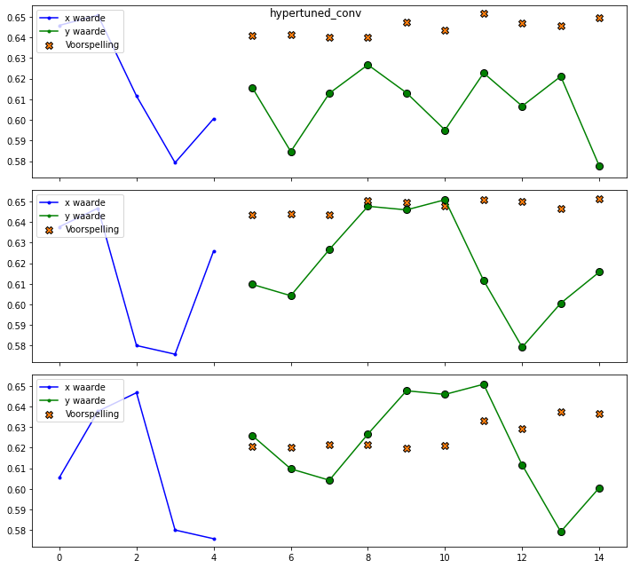

```python
fig = visualize.plot_example(
    valid_set,
    window_size = window_size,
    horizon = horizon,
    examples = 3,
    model = model,
    figurepath = Path("reports/figures"))
```

Het lukt dus niet om door extra features toe te voegen tot een beter model te komen. Maar we kunnen op dit moment eigenlijk nog niet zeggen of de eenvoudige modellen een zinvolle voorspelling geeft. In het volgende notebook kijken we naar de richting van de koersontwikkeling. Mogelijk dat dit tot meer inzicht leidt in de bruikbaarheid van het model.